# 5. час: Просек низа бројева

На овом часу ћеш научити:

1. како да израчунаш просек низа бројева;
2. како да дефинишеш своје функције у Пајтону (а пре свега функцију која рачуна просек); и
3. како да на истом графикону прикажеш и податке и њихов просек.

## 5.1. Просек

Постоји много ситуација када се низ бројева може згодно описати неком *карактеристичном вредношћу*. На пример, ученици добијају оцене из много предмета, али на крају школске године школски систем жели да "изведе" једну оцену и да том оценом окарактерише рад ученика у тој години.

Временом се као најпогоднији представник низа бројева показао *просек*. Просек низа бројева се рачуна овако:

$$ \hbox{просек низа } [x_1, x_2, \dots, x_n] = \frac{x_1 + x_2 + \dots + x_n}{n}. $$

Дакле, да бисмо добили просек низа бројева саберемо све елементе низа и тако добијени број поделимо дужином низа.

У Пајтону се обе ове активности могу обавити позивом одговарајуће уграђене функције: функција `len` рачуна дужину низа, док функција `sum` рачуна збир елемената низа бројева.

На пример:

```python
L = [1, 3, 5, 7, 9, 10]
print(len(L))
print(sum(L))
```

```
6
35
```

(Примети да су ове функције *уграђене у Пајтон* и да нема потребе ловити их по библиотекама!)

Према томе, просек низа бројева се у Пајтону рачуна овако:

```python
print("Prosek niza brojeva", L, "je", sum(L) / len(L))
```

```
Prosek niza brojeva [1, 3, 5, 7, 9, 10] je 5.833333333333333
```

## 5.2. Дефинисање нових функција у Пајтону

Како ћемо у много наврата рачунати просек, дефинисаћемо нову функцију која га рачуна. У претходним разредима смо се већ срели са дефиницијама нових функција у Пајтону и зато мали програм који следи не би требало да представља изненађење за тебе:

```python
def prosek(L):
    return sum(L) / len(L)
```

Претходни програм је у систем унео нову дефиницију: функција `prosek` ће прихватити неки низ `L` и онда ће као резултат свог рада вратити збир елемената низа `L` подељен дужином низа `L` (дакле, просек елемената тог низа).

Примети да је списак Пајтон наредби које представљају *тело функције* и објашњавају шта функција ради увучен за четири празнине.

Да видимо како ради наша нова функција:

```python
print("Prosek niza brojeva", L, "je", prosek(L))
```

```
Prosek niza brojeva [1, 3, 5, 7, 9, 10] je 5.833333333333333
```

У ћелији испод унете су оцене једног ученика из информатике и приказан је њихов просек:

```python
ocene = [5, 3, 5, 4, 4, 5]
print("Prosek ocena iz informatike je", prosek(ocene))
```

```
Prosek ocena iz informatike je 4.333333333333333
```

Ако ћемо искрено, просек оцена се увек приказује заокружен на две децимале. У Пајтону постоји уграђена функција `round(x, n)` која заокружује дати број `x` на `n` децимала. На пример:

```python
round(1.666666666, 2)
```

```
1.67
```

Према томе, просек оцена из информатике сада можемо да добијемо овако:

```python
print("Prosek ocena iz informatike je", round(prosek(ocene), 2))
```

```
Prosek ocena iz informatike je 4.33
```

## 5.3. Приказивање података и њиховог просека

Претпоставимо да је на полугодишту један ученик имао следеће оцене из наведених предмета:

```python
predmeti = ["мат", "срп", "лик", "ист", "физ", "муз", "тио"]
ocene    = [2,     4,     5,     3,     5,     4,     5    ]
```

Желимо да прикажемо његове оцене хистограмом и да просечна оцена буде означена црвеном линијом како бисмо могли да видимо које оцене су изнад просека, а које испод.

Прво ћемо учитати библиотеку за цртање графикона:

```python
import matplotlib.pyplot as plt
```

Хистограм са оценама можемо да нацртамо веома једноставно:

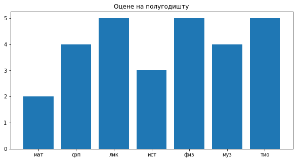

```python
plt.figure(figsize=(10,5))
plt.bar(predmeti, ocene)
plt.title("Оцене на полугодишту")
plt.show()
plt.close()
```

Сада желимо да преко хистограма нацртамо црвену линију која представља просечну оцену. Прво ћемо израчунати просечну оцену `po`:

```python
po = prosek(ocene)
```

а онда ћемо на горњи дијаграм додати и низ података који изгледа овако:

`[po, po, po, po, po, po, po]`

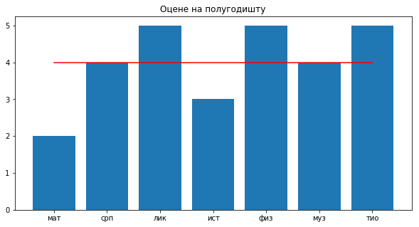

```python
plt.figure(figsize=(10,5))
plt.bar(predmeti, ocene)
plt.plot(predmeti, [po, po, po, po, po, po, po], color="r")
plt.title("Оцене на полугодишту")
plt.show()
plt.close()
```

Ако један исти податак `s` треба поновити `n` пута можемо да пишемо као горе:

`[s, s, s, (и тако даље)]`

али можемо да то запишемо краће овако:

`[s]*n`

Ознаком `[s]*n` смо Пајтону рекли да желимо да направимо нови низ који се добија тако што се низ `[s]` "умножи" `n` пута. На пример, `[5]*7 = [5, 5, 5, 5, 5, 5, 5]`. (Такође је `[6, 7, 8]*3 = [6, 7, 8, 6, 7, 8, 6, 7, 8]`, али нам ово за сада неће бити потребно.)

Тако добијамо следећу верзију програма:

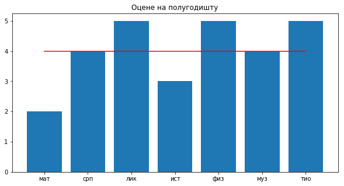

```python
plt.figure(figsize=(10,5))
plt.bar(predmeti, ocene)
plt.plot(predmeti, [po] * len(ocene), color="r")
plt.title("Оцене на полугодишту")
plt.show()
plt.close()
```

За крај ћемо дијаграму додати легенду:

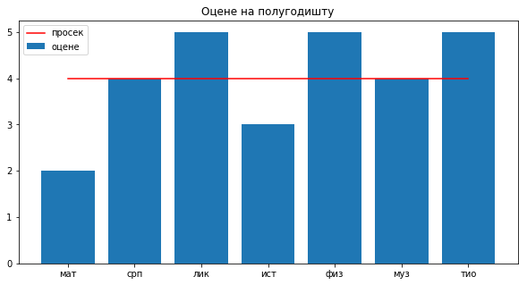

```python
plt.figure(figsize=(10,5))
plt.bar(predmeti, ocene, label="оцене")
plt.plot(predmeti, [po] * len(ocene), color="r", label="просек")
plt.title("Оцене на полугодишту")
plt.legend()
plt.show()
plt.close()
```

## 5.4. Задаци

Задатке уради у Џупајтеру.

**Задатак 1.** Једна збирка кратких прича за децу има 12 страна - по једна прича на свакој страни. Приче имају мали број речи, и то, по странама: 271, 354, 296, 301, 333, 326, 285, 298, 327, 316, 287 и 314. Колики је просечан број речи по причи у овој књизи?

**Задатак 2.**

*(а)* Мирко из музичког има 5, 4, 5 и још једну оцену која се не види јер се преко ње разлило мастило. Просек његових оцена из музичког је 4. Која је то оцена преко које се разлило мастило?

*(б)* Колико још петица Мирко треба да добије да би наставница музичког за крај године морала да му закључи оцену 5? (Према Правилнику о оцењивању у основним школама, ако је просек оцена уписаних у дневник 4,50 или више, наставник *мора* да закључи оцену 5.)

(Помоћ: решење задатка под *(а)* израчунај - за то ти не треба Пајтон; решење задатка под *(б)* можеш да израчунаш, али можеш и да га погодиш тако што ћеш експериментисати са разним могућностима Миркових оцена из музичког - користи функцијe `prosek` и `round`.)

**Задатак 3.** Првих десет места на АТП листи на дан 12.11.2018. изгледа овако:

```python
teniseri = ["Đoković", "Nadal", "Federer", "Del Potro", "Zverev", "Anderson", "Čilić", "Thiem", "Nishikori", "Isner"]
poeni    = [8045,      7480,    6020,      5300,        5085,     4310,       4050,    3895,    3390,        3155]
```

*(а)* Прикажи хистограмом податке о АТП поенима првих десет тенисера на свету, а црвеном линијом прикажи просечан број поена првих десет играча на АТП листи.

*(б)* Колико од њих је изнад просека?

**Задатак 4.** На почетку одељка 5.3. дате су оцене једног ученика на полугодишту. Хистограмом прикажи колико свака од оцена одступа од просека. Следећи Пајтон програмчић ће ти помоћи:

```python
odstupanje = [0] * len(ocene) # овим смо направили низ нула, само да резервишемо простор
for i in range(len(ocene)):
    odstupanje[i] = ocene[i] - po
```